# BIO532 Single-factor ANOVA

Michal L Collyer

```r
knitr::opts_chunk$set(echo = TRUE)
```

# The same examples as in Chapter 6

IMPORTANT! BEFORE GOING FURTHER, DO THESE TWO THINGS in R"

install.packages(“devtools”) (Do this just this once)

devtools::install_github(“mlcollyer/RRPP”, build_vignettes = TRUE) (Do this every script)

The reason for this is that `RRPP` is a packaged published on CRAN but updating it on CRAN takes a long time. Since the instructor is also the `RRPP` author, updates can be made instantly on `Github`. Installing directly from `Githuib` every `R` session means having the latest updates.

# Read in the calluna data

Either use the Import Dataset tab or change working directory to where the `calluna.csv` file is found and run command below. (To change the directory in R Studio: Session –> Set Working Directory –> Choose location. A pop-up window will appear.)

```r
calluna <- read.csv("calluna.csv",
                       header = TRUE,
                       stringsAsFactors = TRUE)

str(calluna) # or view in Environment tab
```

```
## 'data.frame':    56 obs. of  5 variables:
##  $ Site     : Factor w/ 2 levels "Lueneburg Heath",..: 1 1 1 1 1 1 1 2 2 2 ...
##  $ treatment: Factor w/ 4 levels "Control","D",..: 1 1 1 1 1 1 1 1 1 1 ...
##  $ dry.wt   : num  63.3 76.9 25.2 14.5 46.7 47.3 14.4 3.2 9.4 36.6 ...
##  $ cn.ratio : num  41.8 46.1 NA 49.3 40.2 ...
##  $ delta.13C: num  -27.3 -26.5 -28.4 -28.1 -27.4 ...
```

```r
calluna <- calluna[c("treatment", "cn.ratio")] # eliminate unneeded columns
calluna <- na.omit(calluna) # Eliminate rows with NA as values
str(calluna)
```

```
## 'data.frame':    46 obs. of  2 variables:
##  $ treatment: Factor w/ 4 levels "Control","D",..: 1 1 1 1 1 1 1 1 1 1 ...
##  $ cn.ratio : num  41.8 46.1 49.3 40.2 58.5 ...
##  - attr(*, "na.action")= 'omit' Named int [1:10] 3 8 10 15 17 29 33 36 50 52
##   ..- attr(*, "names")= chr [1:10] "3" "8" "10" "15" ...
```

# Plot

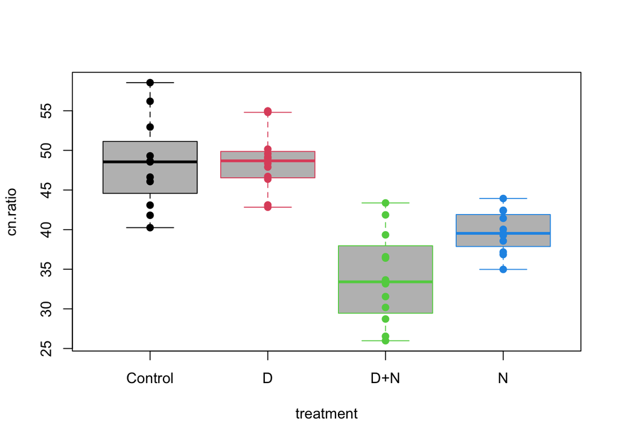

```r
boxplot(cn.ratio ~ treatment, data = calluna,
        border = 1:4, col = "gray")
stripchart(cn.ratio ~ treatment, data = calluna,
           pch = 19, col = 1:4, vertical = TRUE,
           add = TRUE)
```

# State null and alternative hypotheses:

$$H_0: \sigma^2_{Treatment|\mu} = 0$$
$$H_a: \sigma^2_{Treatment|\mu} > 0$$

# Confidence level = 95% ($\alpha = 0.05$)

# Fit linear model

```r
library(RRPP) # open RRPP library

fit1 <- lm.rrpp(cn.ratio ~ treatment,
                data = calluna,
                iter = 9999,
                print.progress = FALSE)
```

# Linear model parts

```r
model.matrix(fit1)
```

```
##    (Intercept) treatmentD treatmentD+N treatmentN
## 1            1          0            0          0
## 2            1          0            0          0
## 3            1          0            0          0
## 4            1          0            0          0
## 5            1          0            0          0
## 6            1          0            0          0
## 7            1          0            0          0
## 8            1          0            0          0
## 9            1          0            0          0
## 10           1          0            0          0
## 11           1          0            0          0
## 12           1          1            0          0
## 13           1          1            0          0
## 14           1          1            0          0
```

[output cut: 37 more lines]

```r
coef(fit1)
```

```
##                     [,1]
## (Intercept)   48.3681818
## treatmentD     0.2126515
## treatmentD+N -14.4223485
## treatmentN    -8.6763636
```

```r
fitted(fit1)
```

```
##  [1] 48.36818 48.36818 48.36818 48.36818 48.36818 48.36818 48.36818 48.36818
##  [9] 48.36818 48.36818 48.36818 48.58083 48.58083 48.58083 48.58083 48.58083
## [17] 48.58083 48.58083 48.58083 48.58083 48.58083 48.58083 48.58083 39.69182
## [25] 39.69182 39.69182 39.69182 39.69182 39.69182 39.69182 39.69182 39.69182
## [33] 39.69182 39.69182 33.94583 33.94583 33.94583 33.94583 33.94583 33.94583
## [41] 33.94583 33.94583 33.94583 33.94583 33.94583 33.94583
```

```r
residuals(fit1)
```

```
##  [1] -6.5581818 -2.2981818  0.9418182 -8.1181818 10.1818182  4.5818182
##  [7]  7.8318182 -1.7381818  0.2718182 -5.2781818  0.1818182 -5.7508333
## [13] -5.4708333  1.5791667  0.9991667 -1.8708333 -0.6808333 -0.2208333
## [19]  6.3891667 -2.2108333  6.2191667  0.5991667  0.4191667 -0.1618182
## [25] -0.4118182 -2.5218182  2.6881818 -1.1218182 -4.7118182 -2.8318182
## [31]  4.2381818  1.7381818  0.3481818  2.7481818 -7.9658333 -0.7758333
## [37]  5.3941667  2.6341667  7.9141667  9.4241667 -7.4058333 -3.7658333
## [43] -2.3958333  2.4641667 -5.2258333 -0.2958333
```

# Residual diagnostics

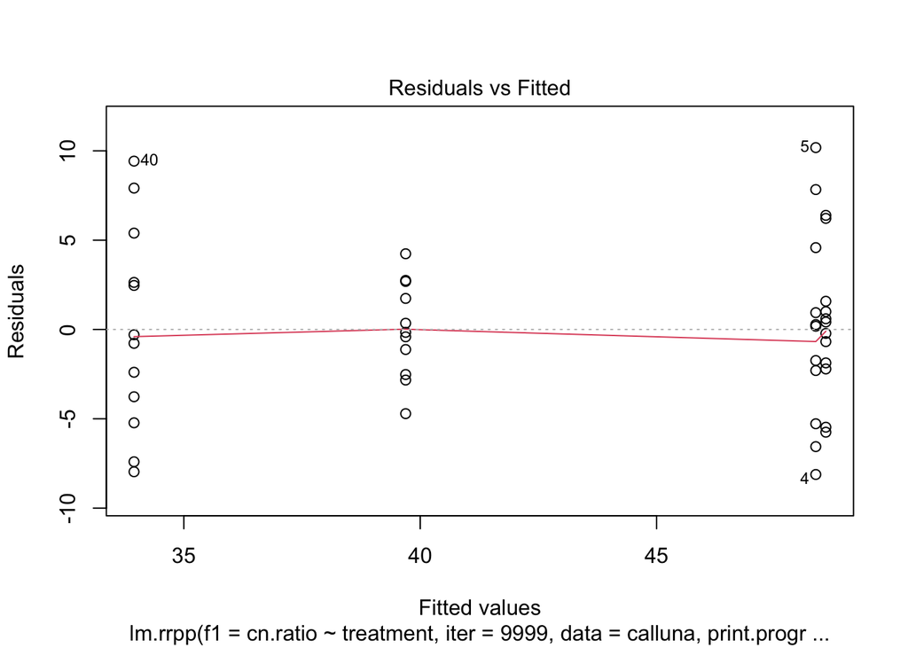

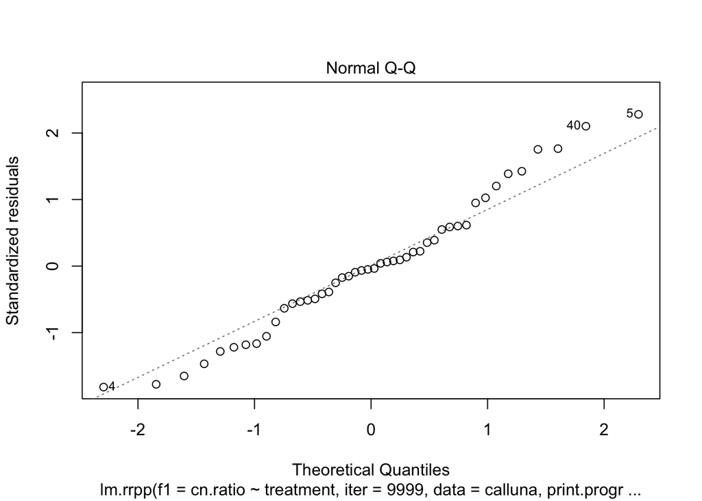

```r
plot(fit1, which = c(1, 2))
```

# Perform ANOVA

```r
anova(fit1)
```

```
##
## Analysis of Variance, using Residual Randomization
## Permutation procedure: Randomization of null model residuals
## Number of permutations: 10000
## Estimation method: Ordinary Least Squares
## Sums of Squares and Cross-products: Type I
## Effect sizes (Z) based on F distributions
##
##           Df      SS     MS     Rsq      F      Z Pr(>F)
## treatment  3 1787.00 595.67 0.65985 27.158 6.1165  1e-04 ***
## Residuals 42  921.19  21.93 0.34015
## Total     45 2708.19
## ---
## Signif. codes:  0 '***' 0.001 '**' 0.01 '*' 0.05 '.' 0.1 ' ' 1
##
## Call: lm.rrpp(f1 = cn.ratio ~ treatment, iter = 9999, data = calluna,
##     print.progress = FALSE)
```

# Conclusion?

### Reject $H_0$; `Treatment` important term in model; $Z$-score suggests it is a large effect

# We are not done !!!

We have multiple potential reasons for why this null hypothesis is rejected.

```r
PW <- pairwise(fit1, groups = calluna$treatment)
summary(PW, confidence = 0.95, show.vectors = TRUE)
```

```
##
## Pairwise comparisons
##
## Groups: Control D D+N N
##
## RRPP: 10000 permutations
##
## LS means:
##             [,1]
## Control 48.36818
## D       48.58083
## D+N     33.94583
## N       39.69182
##
## Pairwise distances between means, plus statistics
##                      d UCL (95%)         Z Pr > d
## Control:D    0.2126515  6.312519 -1.697536 0.9482
## Control:D+N 14.4223485  6.314034  3.394222 0.0001
## Control:N    8.6763636  6.584636  2.134498 0.0084
## D:D+N       14.6350000  6.164208  3.497412 0.0001
## D:N          8.8890152  6.371614  2.238674 0.0048
## D+N:N        5.7459848  6.309261  1.427713 0.0739
```

# Conclusion?